# El calor reduce la fotosíntesis del trigo duro, pero G1 y G3 resisten mejor

Tres hallazgos de un análisis con datos simulados

Autor/a

Paul López

Fecha de publicación

20 de noviembre de 2026

**Datos simulados**

**Todos los datos de esta página son simulados.** Están inspirados en el estudio de trigo duro (*Triticum durum*) bajo calor en antesis, pero no son mediciones reales ni resultados de ninguna investigación. Sirven para practicar el análisis y la comunicación, no para sacar conclusiones agronómicas.

## Contexto

El trigo duro es la base de la pasta y el cuscús, y es sensible al calor justo cuando florece (antesis). Las revisiones coinciden en que el calor en esa etapa reduce el rendimiento del trigo (Ullah et al. 2022; Mirosavljević et al. 2024), y también se ha observado en trigo duro en condiciones de campo (Groli et al. 2024).

Si algunas variedades aguantan mejor, se podrían priorizar para sembrar o mejorar. La literatura sugiere pistas: los genotipos tolerantes tienden a acumular más prolina y la fertilización con potasio ayuda a mitigar el efecto del calor (Khan et al. 2020); además, los cultivares que mantienen un Fv/Fm alto bajo calor conservan más fotosíntesis y conductancia estomática (Sharma et al. 2015). Aquí usamos datos simulados para ilustrar cómo se mostraría algo así.

**Pregunta guía:** ¿sufren todos los genotipos el calor por igual, o algunos sostienen mejor su fotosíntesis? ¿Qué pasa con su potasio y su prolina?

**¿Qué medimos?**

- **Fotosíntesis neta (A<sub>net</sub>):** cuánto CO<sub>2</sub> captura la hoja por segundo y por metro cuadrado (µmol CO<sub>2</sub> m⁻² s⁻¹). Más es mejor.
- **Potasio (K):** nutriente de la hoja que ayuda a abrir y cerrar los estomas (mg por gramo de materia seca, mg g⁻¹).
- **Prolina:** compuesto protector que la planta acumula cuando sufre estrés (abundancia relativa, en unidades arbitrarias, u.a.).
- **Diseño:** 5 genotipos (G1–G5) × 2 tratamientos (Control y Calor) × 4 bloques = 40 plantas.

## Hallazgo 1: el calor reduce la fotosíntesis neta un 43,1 %

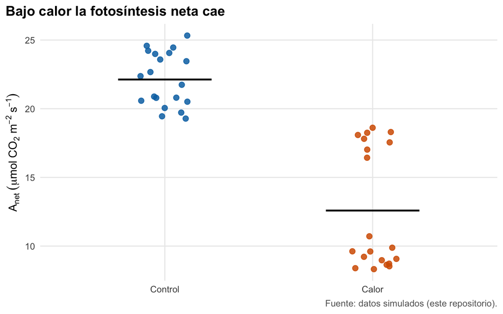

Figura 1: Fotosíntesis neta (µmol CO2 m-2 s-1) por tratamiento. Cada punto es una planta (n = 20 por tratamiento); la barra negra es la media.

Tabla 1: Media ± desviación estándar por tratamiento (n = 20 por tratamiento) y cambio porcentual de Calor frente a Control.

| Variable | Control | Calor | Cambio (%) |
| --- | --- | --- | --- |
| A_net (µmol CO2 m-2 s-1) | 22,1 ± 2,0 | 12,6 ± 4,4 | -43,1 |
| gs (mol H2O m-2 s-1) | 0,32 ± 0,04 | 0,16 ± 0,03 | -49,6 |
| Fv/Fm (adimensional) | 0,82 ± 0,01 | 0,72 ± 0,06 | -11,6 |

La fotosíntesis neta baja de 22,1 a 12,6 µmol CO<sub>2</sub> m⁻² s⁻¹. Con el calor también se cierran los estomas (menor gs) y baja la eficiencia del fotosistema (Fv/Fm). Los puntos bajo calor se reparten en dos grupos, lo que anticipa que no todos los genotipos responden igual.

## Hallazgo 2: G1 y G3 pierden solo un 27 % de fotosíntesis bajo calor, frente a 56 % del resto

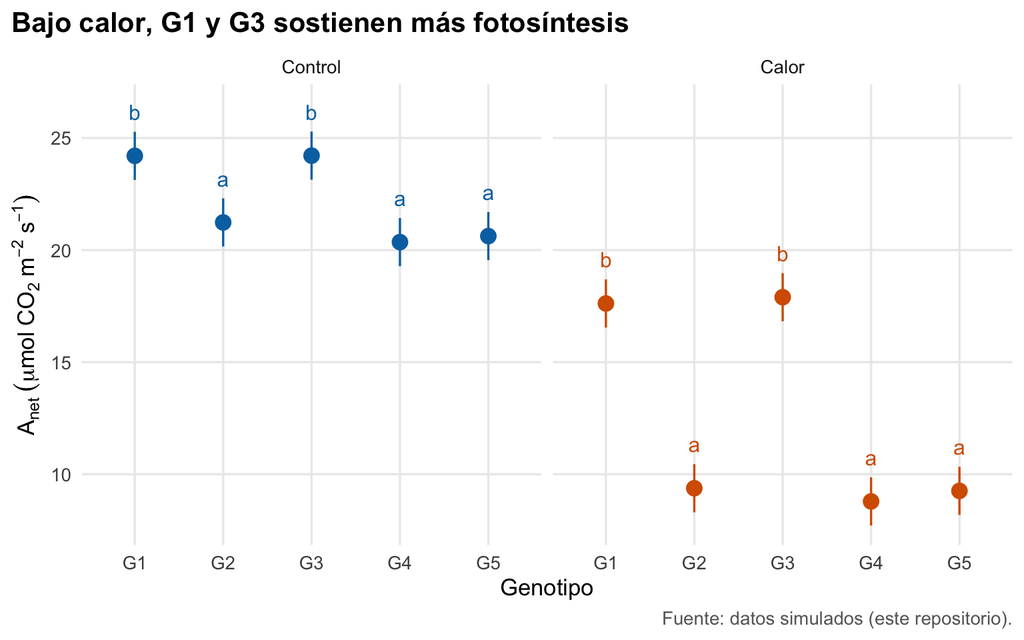

Figura 2: Fotosíntesis neta media estimada (µmol CO2 m-2 s-1) por genotipo y tratamiento, con intervalo de confianza del 95 % (modelo lineal con tratamiento × genotipo + bloque; n = 4 por combinación). Las letras comparan genotipos dentro de cada tratamiento (Sidak); letras distintas indican diferencias.

Tabla 2: Fotosíntesis neta media por genotipo (µmol CO2 m-2 s-1; n = 4 por combinación), cambio porcentual y letra de comparación bajo calor.

| Genotipo | A_net Control | A_net Calor | Cambio (%) | Letra en calor |
| --- | --- | --- | --- | --- |
| G1 | 24,2 | 17,6 | -27,2 | b |
| G2 | 21,2 | 9,4 | -55,8 | a |
| G3 | 24,2 | 17,9 | -26,1 | b |
| G4 | 20,4 | 8,8 | -56,8 | a |
| G5 | 20,6 | 9,3 | -55,1 | a |

Bajo calor, G1 y G3 conservan entre 17,6 y 17,9 µmol CO<sub>2</sub> m⁻² s⁻¹, mientras que el resto queda entre 8,8 y 9,4. Las letras de la tabla indican qué genotipos se distinguen estadísticamente bajo calor. Con solo cuatro plantas por combinación, los intervalos son amplios y conviene leerlo como una pista, no como una prueba definitiva.

## Hallazgo 3: bajo calor, los genotipos con más potasio mantienen más fotosíntesis (ρ = 0,61), y la prolina sube un 58 %

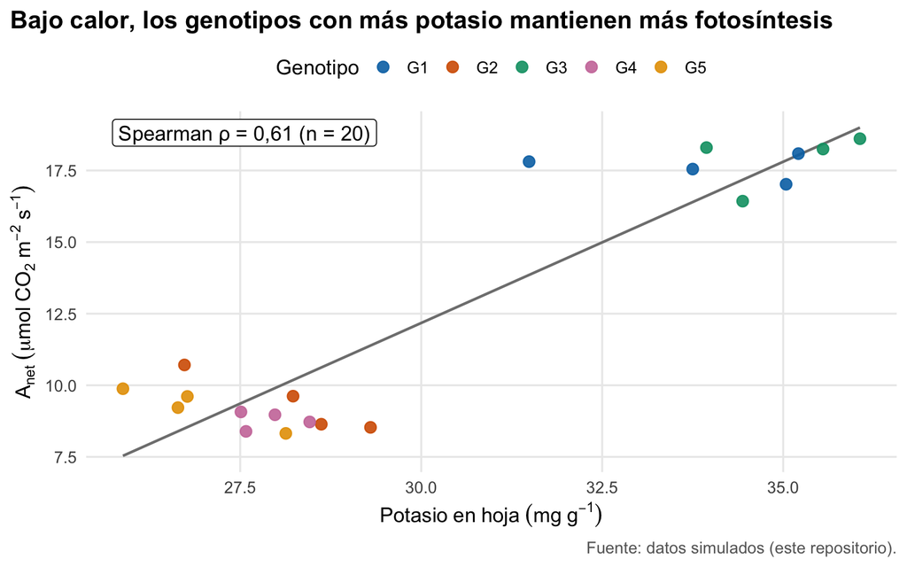

Figura 3: Fotosíntesis neta (µmol CO2 m-2 s-1) frente a potasio en hoja (mg g-1) en las plantas bajo calor (n = 20). Color por genotipo; recta de ajuste lineal.

Tabla 3: Cambio porcentual de potasio (mg g-1) y prolina (u.a.) de Calor frente a Control, por genotipo (n = 4 por combinación).

| Genotipo | Potasio: cambio (%) | Prolina: cambio (%) |
| --- | --- | --- |
| G1 | -9,8 | 38,5 |
| G2 | -26,3 | 86,1 |
| G3 | -10,2 | 57,3 |
| G4 | -27,4 | 48,5 |
| G5 | -31,9 | 60,1 |

En promedio, el potasio cambia un -21,2 % y la prolina un 57,6 % bajo calor. La prolina es un compuesto protector que la planta produce ante el estrés, así que su aumento es coherente con plantas bajo presión. La relación entre potasio y fotosíntesis es moderada y en buena parte refleja diferencias entre genotipos: no permite afirmar que el potasio *cause* una mayor fotosíntesis.

## Vista general: las tres capas a la vez

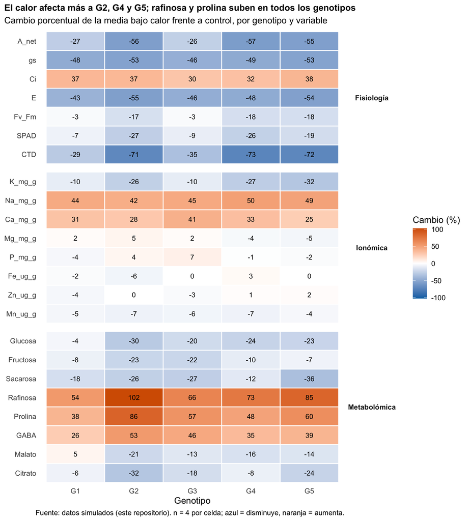

Figura 4: Cambio porcentual de la media bajo calor frente a control, por genotipo y variable, agrupado por capa (fisiología, ionómica y metabolómica). Azul = disminuye, naranja = aumenta; n = 4 por celda. Fuente: datos simulados (este repositorio).

El mapa resume 23 variables de las tres capas. La mayoría de las variables de fisiología cae con el calor en todos los genotipos (por ejemplo, la conductancia estomática baja entre 46 % y 53 %), mientras que sodio y calcio suben. En metabolómica, la rafinosa y la prolina aumentan en los cinco genotipos; la rafinosa llega a +102 % en G2.

Las caídas de fotosíntesis, potasio y clorofila (SPAD) son más moderadas en G1 y G3 (por ejemplo, SPAD -7 % y -9 %) que en G2, G4 y G5 (-27 %, -26 % y -19 %). Es una vista de apoyo a los tres hallazgos anteriores, no un cuarto resultado.

## ¿Qué significa?

- El calor reduce de forma clara la fotosíntesis neta (-43,1 %) y acompaña cambios en el potasio (-21,2 %) y la prolina (+57,6 %).
- Los genotipos **G1 y G3** son los que mejor sostienen la fotosíntesis bajo calor: serían los primeros candidatos a estudiar.
- Que las plantas con más potasio mantengan más fotosíntesis es una hipótesis que merece probarse en un experimento real.

## Limitaciones

- **Datos simulados:** ilustran el análisis; no son evidencia agronómica.
- **Muestra pequeña:** solo 4 plantas por genotipo y tratamiento.
- **Correlación no es causalidad:** la relación potasio–fotosíntesis puede deberse al genotipo.
- **Un solo ambiente:** no sabemos si el patrón se repetiría en otros sitios o años.

## Cómo se hizo

Todo el análisis es reproducible y está en el repositorio Trigo-estres-termico:

- Limpieza, validación e integración de las tres capas de datos: [`scripts/01_eda.R`](https://github.com/Palp311/Trigo-estres-termico/blob/main/scripts/01_eda.R).
- Descripción de cada variable: [`data/diccionario_datos.csv`](https://github.com/Palp311/Trigo-estres-termico/blob/main/data/diccionario_datos.csv).
- Validación de los datos contra el diccionario: [`reports/validacion.md`](https://github.com/Palp311/Trigo-estres-termico/blob/main/reports/validacion.md).
- Versiones de paquetes: [`renv.lock`](https://github.com/Palp311/Trigo-estres-termico/blob/main/renv.lock).
- Anexos: informe borrador y exploración de Quarto.

El modelo es un modelo lineal de la fotosíntesis neta con tratamiento × genotipo + bloque; las comparaciones entre genotipos usan medias marginales estimadas (`emmeans`) con ajuste de Sidak.

## Referencias

Groli, Eder Licieri, Elisabetta Frascaroli, Marco Maccaferri, Karim Ammar, y Roberto Tuberosa. 2024. «Dissecting the effect of heat stress on durum wheat under field conditions». *Frontiers in Plant Science* 15: 1393349. https://doi.org/10.3389/fpls.2024.1393349.

Khan, Adeel, Munir Ahmad, Mukhtar Ahmed, y M. Iftikhar Hussain. 2020. «Rising atmospheric temperature impact on wheat and thermotolerance strategies». *Plants* 10: 43. https://doi.org/10.3390/plants10010043.

Mirosavljević, Milan, Sanja Mikić, Vesna Župunski, et al. 2024. «Effects of heat stress during anthesis and grain filling stages on some physiological and agronomic traits in diverse wheat genotypes». *Plants* 13: 2083. https://doi.org/10.3390/plants13152083.

Sharma, Dew Kumari, Sven Bode Andersen, Carl-Otto Ottosen, y Eva Rosenqvist. 2015. «Wheat cultivars selected for high Fv/Fm under heat stress maintain high photosynthesis, total chlorophyll, stomatal conductance, transpiration and dry matter». *Physiologia Plantarum* 153: 284-98. https://doi.org/10.1111/ppl.12245.

Ullah, Aman, Faisal Nadeem, Ahmad Nawaz, Kadambot H. M. Siddique, y Muhammad Farooq. 2022. «Heat stress effects on the reproductive physiology and yield of wheat». *Journal of Agronomy and Crop Science* 208: 1-17. https://doi.org/10.1111/jac.12572.